# Central Coast coho analysis updates

31 October, 2025

# 1 About

This document summarizes preliminary updates to the analyses described in [Wilson et al. 2025](https://cdnsciencepub.com/doi/full/10.1139/cjfas-2025-0023) including:

- Updated spawner estimates, where available, through 2024 (file [here](https://github.com/Pacific-salmon-assess/CC_coho/blob/main/Data/Coho_Brood_MASTER_2025_updateDQ.xlsx)). Previous estimates were through 2020.
- Updated harvest rate time series based on the most recent estimates Will A. generated with the updated CWT indicator stock time series Ryan W. provided (file [here](https://github.com/Pacific-salmon-assess/CC_coho/blob/main/Data/CO%20ERs%20by%20CUs.csv))
- Decomposed the Bella Coola spawner timeseries used in Wilson et al. 2025 (which ended in 2007) into separate time series for a handful of tribs that had decent temporal coverage including counts in recent decade (i.e., fish_creek, habensborg_slough, molly_walker, noohalk_ck, nookliklonnik_ck, snootli_ck, thorsen_ck)
- Assumed all fish mature as 3 or 4 year olds by lumping the very tiny (<0.05%) assumed contribution of 5 year olds together with 4 year olds. This allows for a greater number of “complete” spawner-recruitment observations
- Adapted the AR-1 time varying model from Wilson et al. 2025 (JAGS model [here](https://github.com/Pacific-salmon-assess/CC_coho/blob/main/JAGS/model_fitting%20tr1%20extra%20variance.jags)) to have separate variances for spawner observations that were deemed to be of “high” and “low / unknown” or unknown quality, and then fit to the updated data described above.
- Updated the regional productivity~sst relationships/fits.
- Visualized population level estimates of spawner abundance over time to help shed light on observed trends in recent years.

These analyzes explicitly try to account for variable confidence in observations of spawner abundance for those systems that have had a detailed review of SILs (steam inspection logs) by NC StAD. This is done by assuming a much larger variance on observations of low (or unknown) quality in the model likelihood than those that have been identified as high quality.

Code to reproduce analysis, and this doc, can be found [here](https://github.com/Pacific-salmon-assess/NCC_coho).

# 2 Reconstructed harvest rates

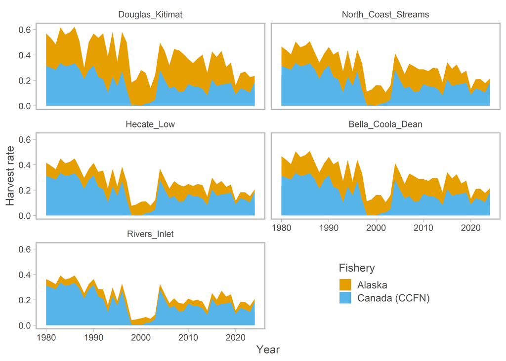

Reconstructed Alaskan and Canadian harvest rates across all fisheries by region. Estimates are based on CWT indicaotr stocks in Northern British Columbia and assumptions about vulnerability of Central Coast coho to fisheries in Alaska and Canada

# 3 Coho populations

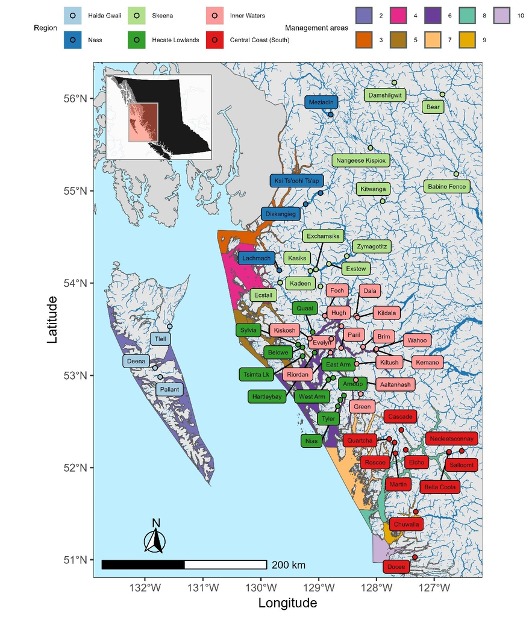

Coho populations origionally included in Wilson et al. 2025, by Management Area and Region. Populations from the Central Coast Regions were the focus of the updated analysis in this document

# 4 Trends in productivity

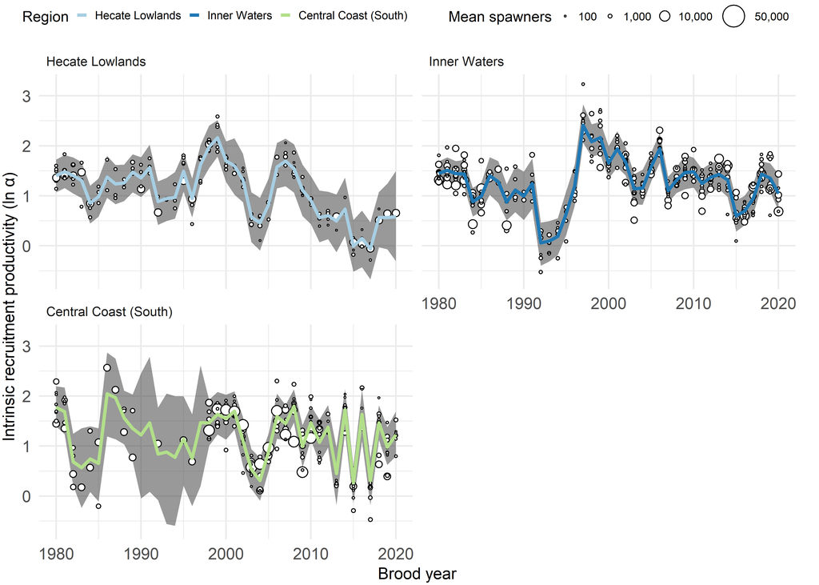

Trends the intrinsic productivity for coho salmon populations within three regions in the Central Coast (lines indicate region-specific posterior median, and the shaded regions indicating 95% credible intervals).

# 5 SST relationships

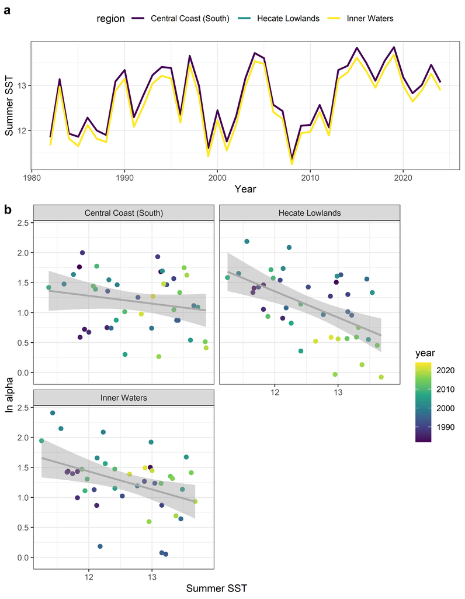

Sea surface temperatures (SSTs) in summer of coho ocean entry year by region and over time (a) and relationshiops between SST and regional intrinsic productivity by region (b).

# 6 Returns by population over time

For systems that have had a detailed review of SILs (steam inspection logs) those reconstructions of total returns that are considered high quality are labelled “high” and colored red. Long-term average returns is denoted with a dashed grey line.

## 6.1 Hecate lowlands

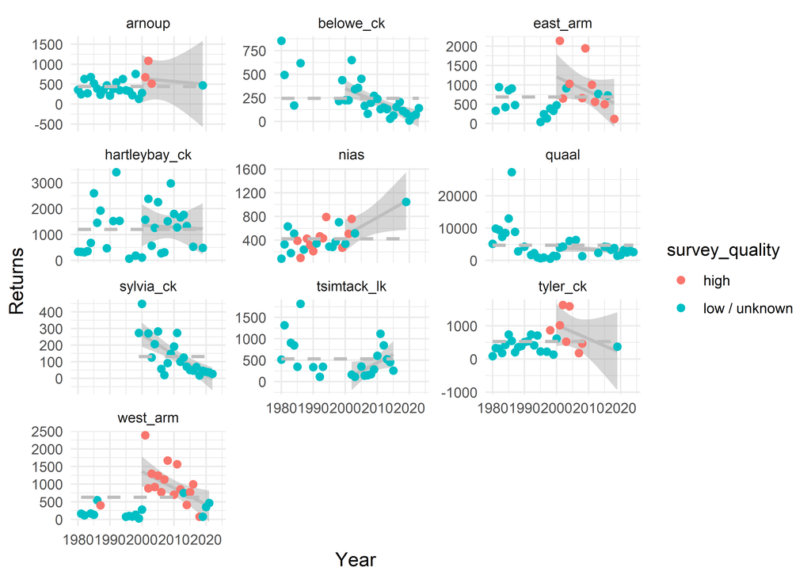

## 6.2 Inner waters

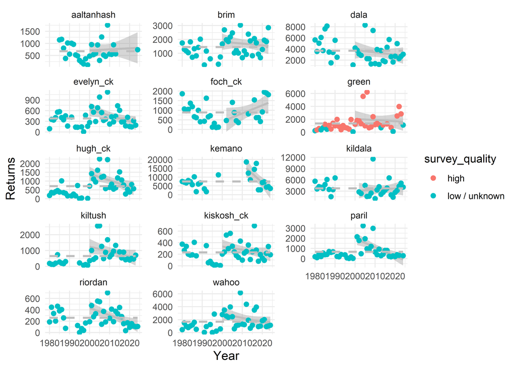

## 6.3 Central Coast (South)

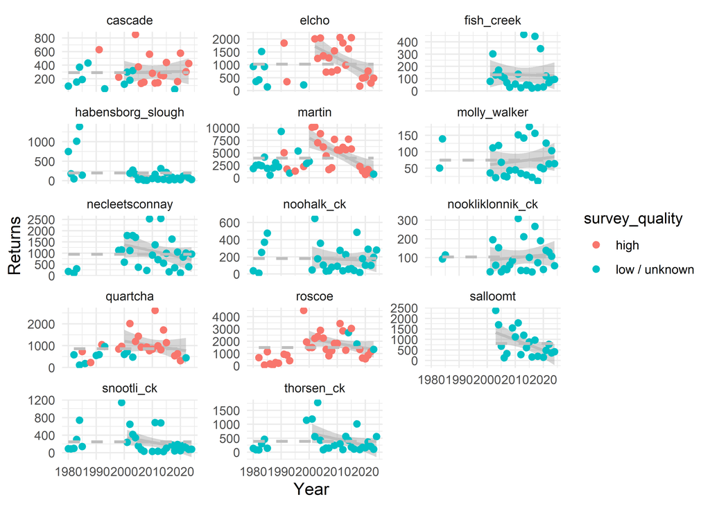

# 7 Spawners by population over time

For systems that have had a detailed review of SILs (steam inspection logs) those observations that are considered high quality are labelled “high” and colored red. Long-term average spawner abundance is denoted with a dashed grey line.

## 7.1 Hecate lowlands

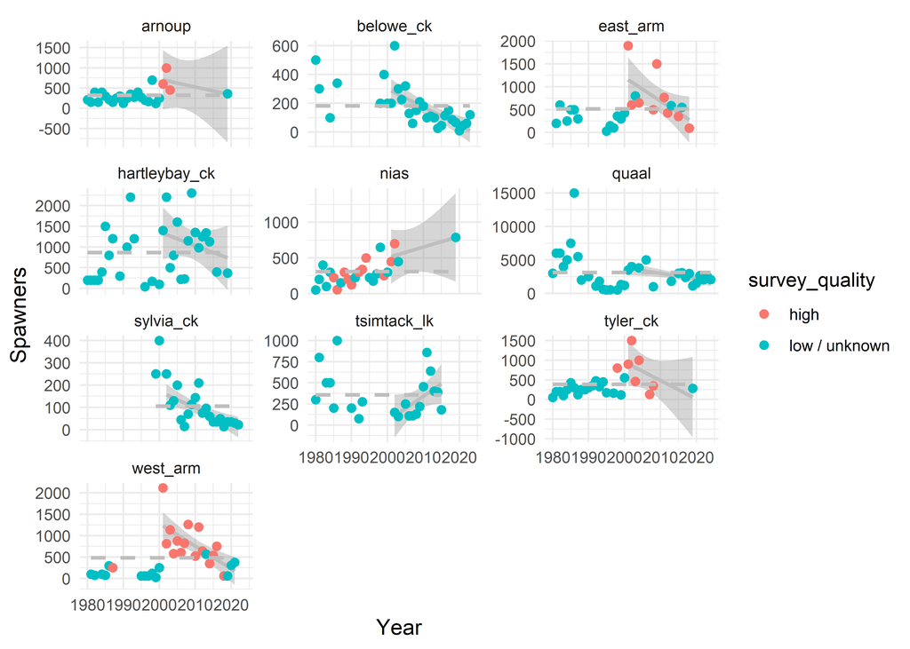

Estimated percent change in spawner abundance, by population and across all populations within region, over last 3 generations (12 years) based on hierarchical model fit to all observations across populations post “coho crisis”.

| population | % change (3-gen) |
| --- | --- |
| arnoup | -39 |
| belowe_ck | -64 |
| east_arm | -57 |
| hartleybay_ck | -32 |
| nias | -11 |
| quaal | -22 |
| sylvia_ck | -65 |
| tsimtack_lk | 33 |
| tyler_ck | -54 |
| west_arm | -64 |
| region | -43 |

## 7.2 Inner waters

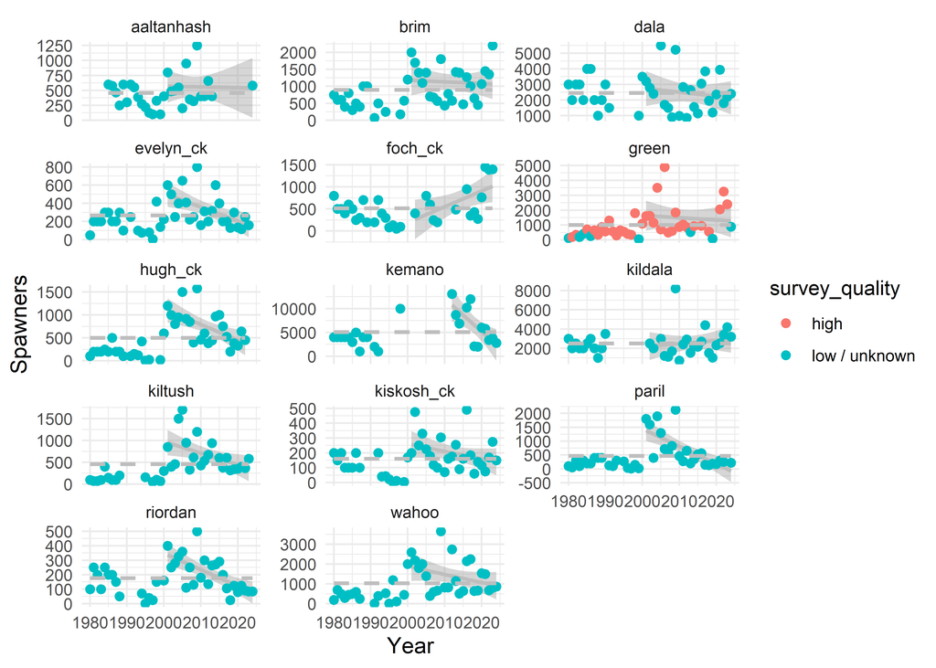

Estimated percent change in spawner abundance, by population and across all populations within region, over last 3 generations (12 years) based on hierarchical model fit to all observations across populations post “coho crisis”.

| population | % change (3-gen) |
| --- | --- |
| aaltanhash | -14 |
| brim | -12 |
| dala | -9 |
| evelyn_ck | -42 |
| foch_ck | 24 |
| green | -21 |
| hugh_ck | -40 |
| kemano | -27 |
| kildala | 11 |
| kiltush | -33 |
| kiskosh_ck | -31 |
| paril | -61 |
| riordan | -51 |
| wahoo | -25 |
| region | -27 |

## 7.3 Central Coast (South)

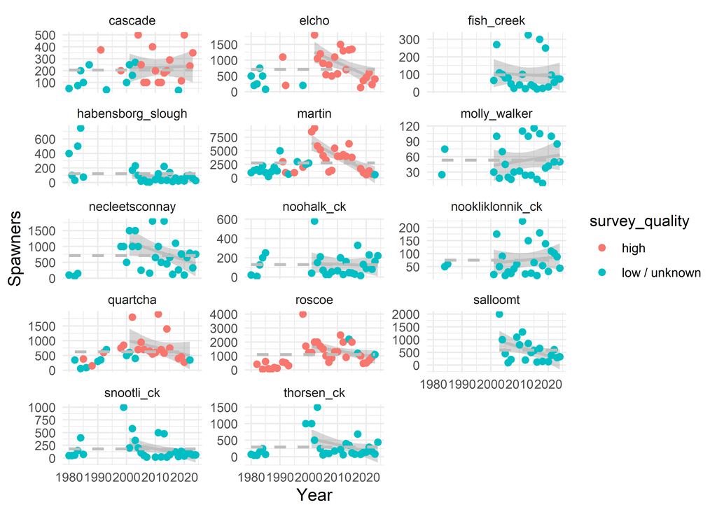

Estimated percent change in spawner abundance, by population and across all populations within region, over last 3 generations (12 years) based on hierarchical model fit to all observations across populations post “coho crisis”.

| population | % change (3-gen) |
| --- | --- |
| cascade | -23 |
| elcho | -44 |
| fish_creek | -3 |
| habensborg_slough | 5 |
| martin | -59 |
| molly_walker | 9 |
| necleetsconnay | -42 |
| noohalk_ck | -8 |
| nookliklonnik_ck | 2 |
| quartcha | -42 |
| roscoe | -50 |
| salloomt | -38 |
| snootli_ck | -11 |
| thorsen_ck | -26 |
| region | -27 |